# Aderência dos Senadores em votações de plenário

### Resumo

Analisamos os senadores que mais seguem e o menos “obedientes” ao governo nas votações nominais de plenário do Senado Federal ocorridas em 2019.

### O que é aderência

Aderência é uma faceta da atuação dos Deputados e Senadores Federais nas votações em plenário de cada casa. Um parlamentar é aderente ao Governo quando segue as orientações do Governo em votações nominais. Neste relatório, focamos nos senadores.

A orientação do governo é feita com base no voto do Líder do Governo. Quando ele não está presente, consideramos o voto do Vice-líder.

Para cada votação de cada senador, identificamos se ele seguiu a orientação do Governo ou não. Em seguida, calculamos o grau de aderência como a proporção das votações em que ele seguiu a orientação do Governo.

Ao total temos 23 votações em plenário.

## Aderência ao Governo

### Quem tem menos aderência?

Abaixo temos os 20 senadores que possuem menos aderência ao governo. Eles estão ordenados pela frequência dos votos em que não seguiram a orientação do Governo. Esta frequência é definida como **nº de votos que seguiu / nº de votos totais** que o senador teve, ignorando os casos onde o senador faltou.

[figure not shown]

É possível observar os senadores que frequentemente seguem menos a orientação do governo: o partido que possui senadores menos aderentes é o PODEMOS, representados por Eduardo Girão, Oriovisto Guimarães, Lasier Martins, Alvaro Dias e Elmano Férrer. Pode-se ver também outros partidos de direita, até o próprio PSL, que é o partido do presidente do Brasil.

### Mais detalhes sobre quem não adere

No gráfico abaixo, é possível detalhar os votos dos senadores menos aderentes ao Governo.

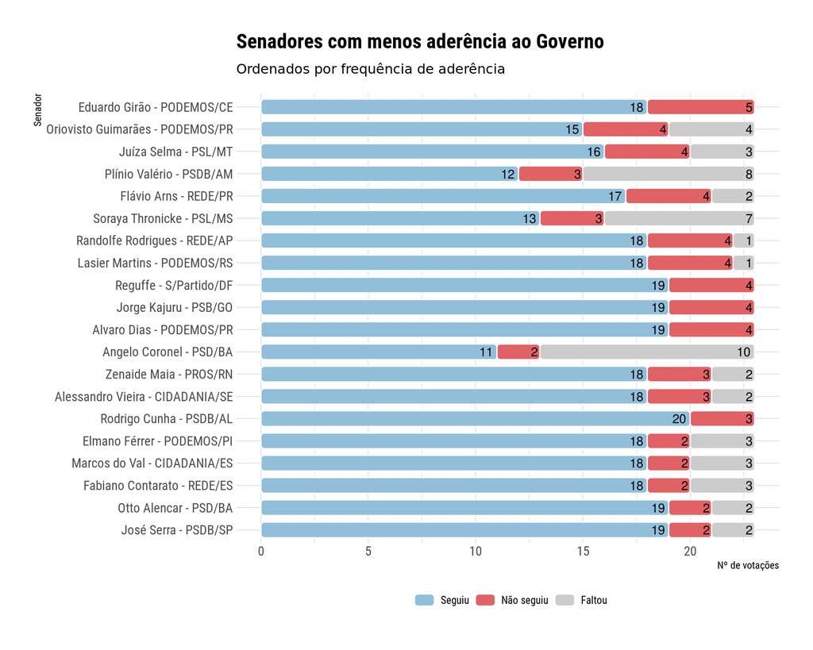

### Quem tem mais aderência?

[figure not shown]

Abaixo detalhamos o resultado dos senadores mais frequentemente aderentes ao Governo.

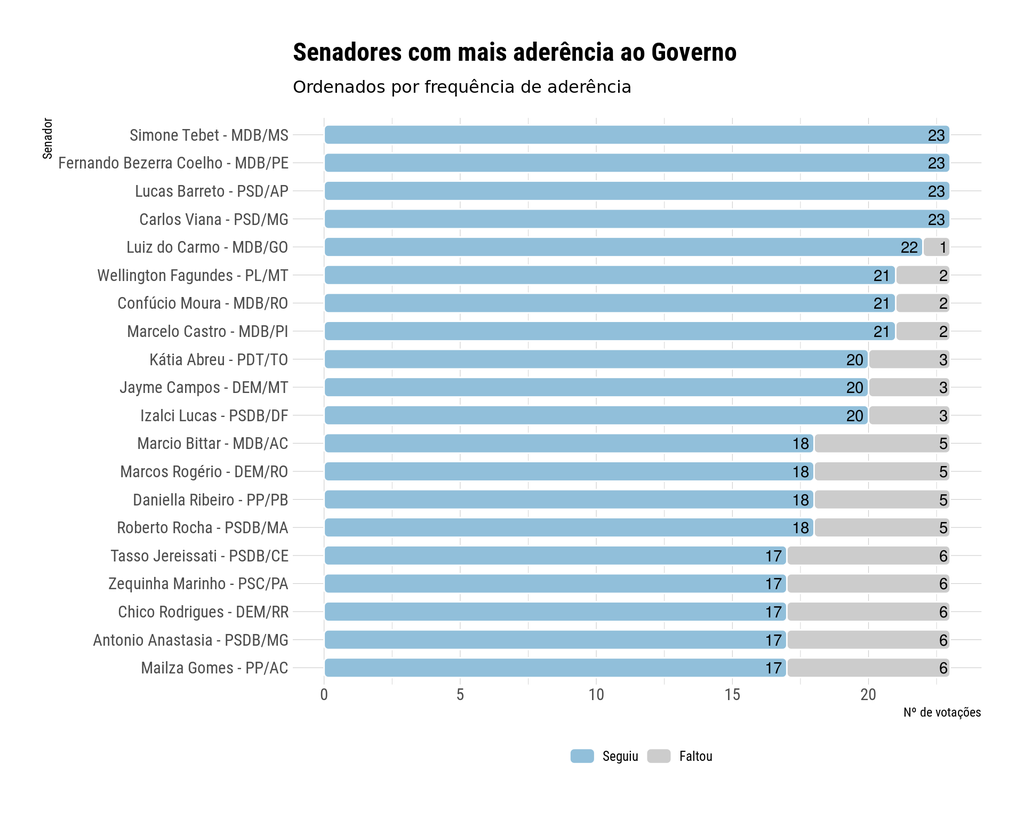

### Aderência nos partidos

Abaixo é possível analisar como os partidos políticos seguem a orientação do Governo.

A marca “**|**” demarca a mediana das aderência dos senadores por partido; ou seja, o traço no gráfico é o valor que separa a metade é mais frequentemente aderente da outra metade com menor frequência. O tamanho do ponto é proporcional ao número de senadores com mesma aderência: quanto maior, mais senadores aglomerados com aderências iguais.

[figure not shown]

Alguns partidos possuem metade de seus representantes com aderência máxima: PSDB, PSC, PRB, PDT, MDB e DEM; isso é indicado pela mediana igual a 100%. Entre os partidos cujo senadores frequentemente não aderem ao governo estão REDE, PODEMOS e PSL. Os demais partidos possuem aderência com maior variância, mas todos ainda bastante aderentes, alternando entre 85% a 100%.

### Aderência nas Comissões

A seguir, analisaremos como as comissões compostas pelos senadores seguem a orientação do Governo.

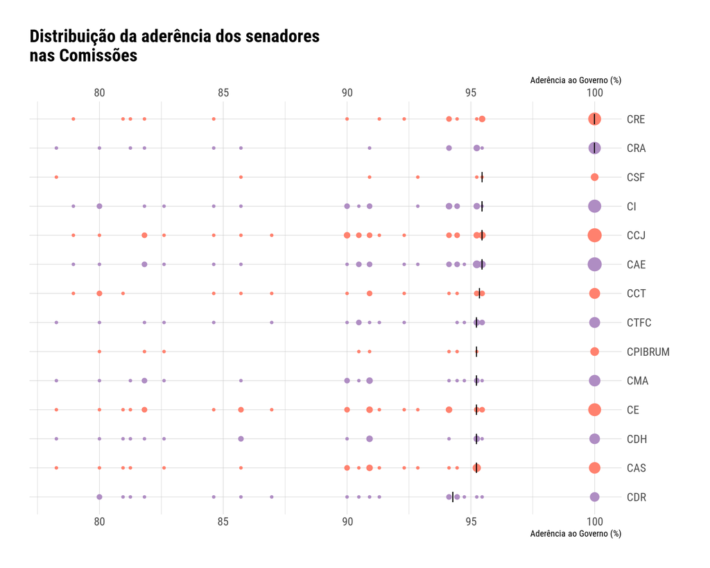

Pode-se visualizar que, nas comissões, metade dos senadores que as compõe geralmente se concetra em torno dos 100% de aderência ao Governo; a outra metade se mostra bem diversa, com senadores que possuem aderências variando de 78% a 95%.